# Neural Progenitor Cells for Treatment of Spinal Cord Injury

## Data modifications

- **Normalisation:** Each expression value (i.e. for each day, animal and target) is divided (i.e. normalised) by the mean of the expression for the same target in healthy (none injured, none transplanted) animals.
- **Outliers:** All observations wiht normalised expression value > 20 are removed. This cut-off is based in plotting of histogram. IL-7 is completely removed due to heavy influence of outliers.

## Statistical analysis

### Evaluation of assumptions

- **Assumption of normality** is evaluated using Shapiro Wilk’s test for each treatment (group) within each time point and for each target separately. Null hypothesis is that data is normally distributed.
- **Assumption of homogenity** of variances is between the two treatments (groups) within each time point and for each target. Given that at least one of the groups did not follow a normal distribution the homogenity of variances was evaluated using Fligner Killeen’s test.

### Independent intraday two group comparison

- Given that data in both treatments (groups) was normally distributed and the variances were equal the groups were compared using two-sided non-paired Student’s t-test. Given that data in both treatments (groups) was normally distributed but the groups and unequal variances the variance was estimated separately for eah group and the Welch modification to the degrees of freedom was used.
- Given that data in at least one of the groups was not normally distributed a two-sided non-paired Wilcoxon Rank Sum test with continuity correction in the normal approximation for the p-value was calculated.

### Agglomerative hierarchical clustering

- Mean expression for each cytokine/chemokine, day and treatment are clustered using agglomerative hierarchical clustering and presented with heatmap.

### Independent multiple group comparison over time

- Changes in expression of each cytokine/chemokine was analyzed over time. Assumtpion of normality and homogenity of variances were evaluated as described above. In case data was normally distributed at all time points for a target and treatment, and the variances where homogenous the difference was evaluated using one-way ANOVA. In case the data was normally distributed but the variances were not homogenous the difference was assessed using Welch ANOVA. the assumption that ANOVA is robust against data deviating from normality was applied.
- Post hoc comparisons were conducted using Tukey’s post hoc test given that one-way (independent group) ANOVA was used and pairwise Mann Whitney U tests with holm-bonferroni correction was used given that Kruskal Wallis H test was used for multiple group comparison.

### Open source access

The R-script and html-report can both be accessed at [github](https://github.com/S-B-lab/SCI_NPC_multiplex). Please feel free to fork or make a pull request.

## Pro-inflammation over time

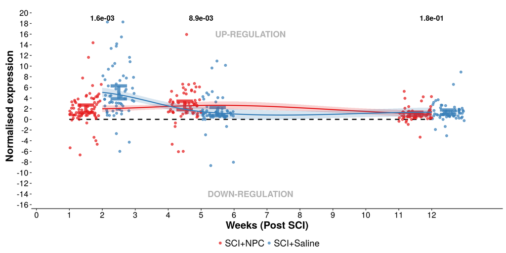

**Figure 1:** Figure reports pro-inflammation (IL-1a, IL-1b, IL-5, IL-6, IL-12(p70), IL-17, IL-18, GM-CSF, GRO/KC, IFN-g, MCP-1, MIP-1a, MIP-3a, RANTES, TNF-a) over time for each treatment group. P-values are average p-values of 1000 bootstrapped replicates of independent two group comparison using assumptions and test selection as described above.

## Sensitivity analysis of pro-inflammation over time

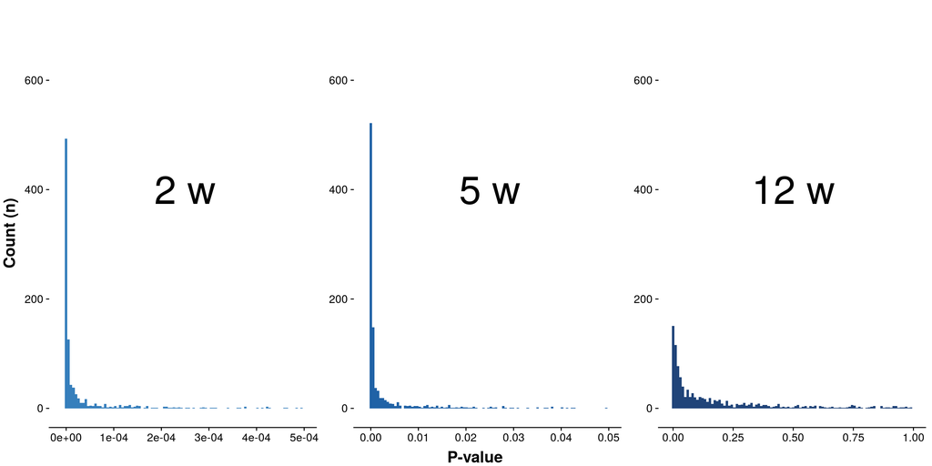

**Figure 2:** Figure reports histograms of 1000 p-values calculated on bootstrapped data for pro-inflammation from each group at each time point.

| 2w | 5w | 12w |
| --- | --- | --- |
| 2.8e-06 | 2.1e-04 | 6.8e-02 |

**Table 1:** Median p-values for 1000 p-values for independent two group comparison based on bootstrapped data for pro-inflammatory data.

## Agglomerative hierarchical clustering

### **2 weeks post SCI**

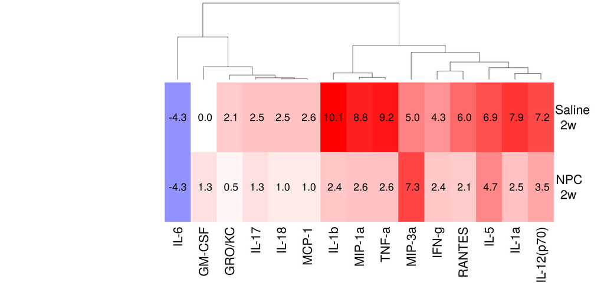

### **5 weeks post SCI**

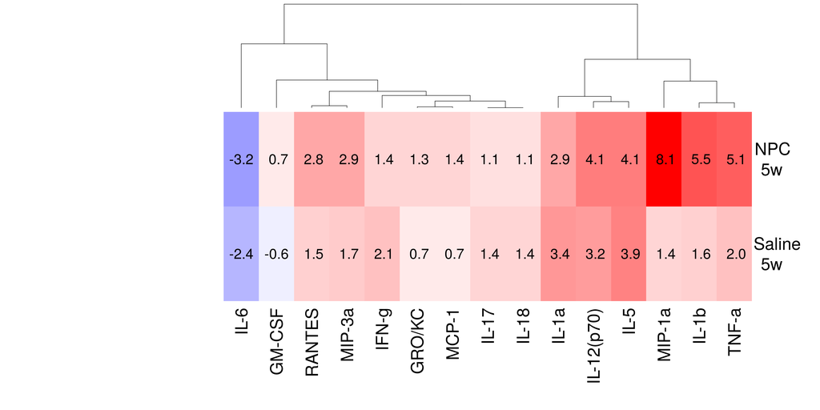

### **12 weeks post SCI**

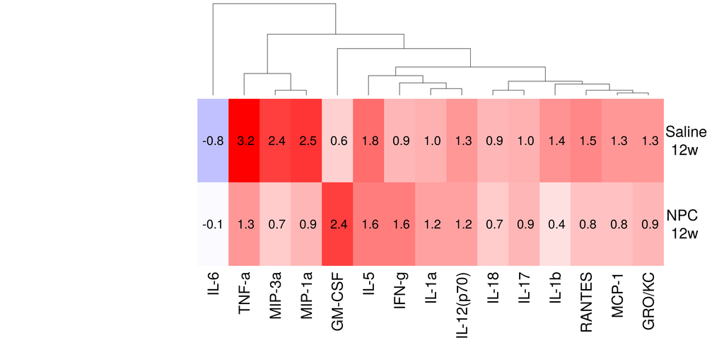

### **2, 5 and 12 weeks**

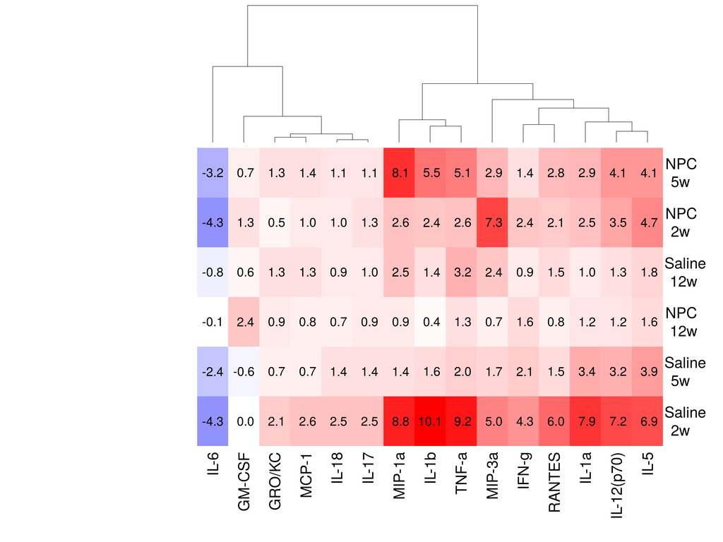

**Figur 3:** Figure reports agglomerative hierarchical clustering with heatmap of pro-inflammatory cytokines/chemokines for each treatment. Data reported at 2, 5 and 12 weeks separately and jointly.

## Individual cytokines over time

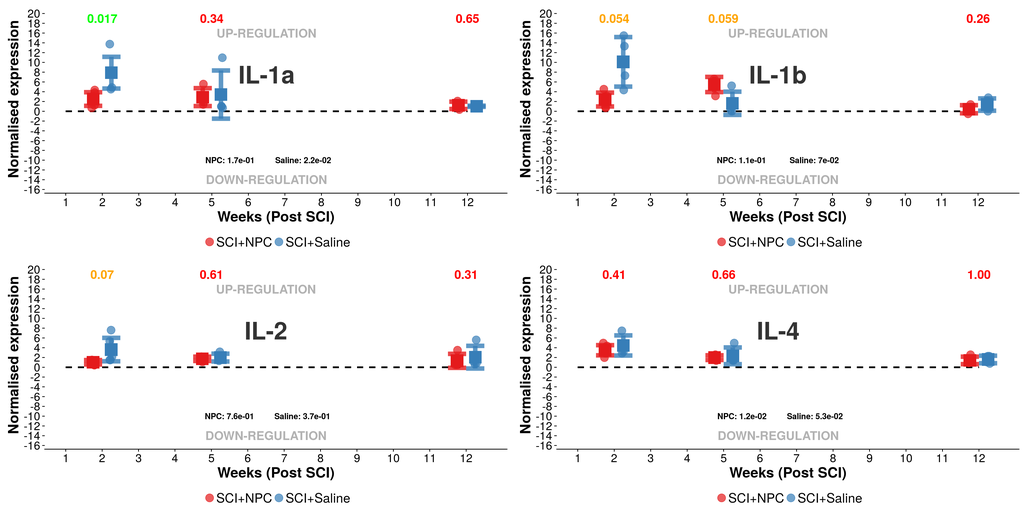

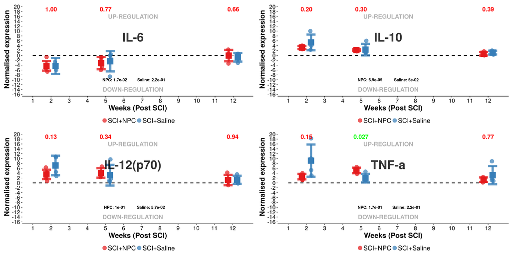

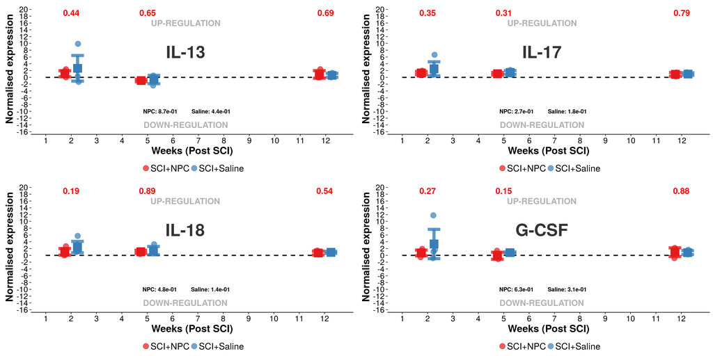

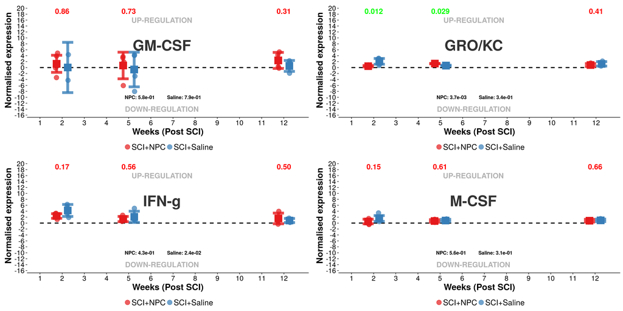

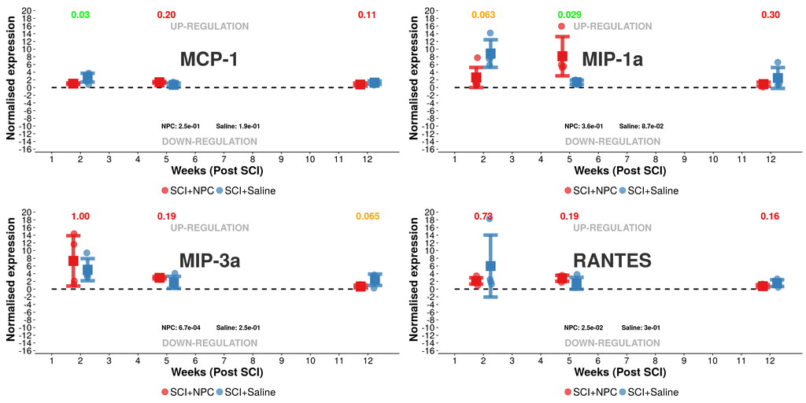

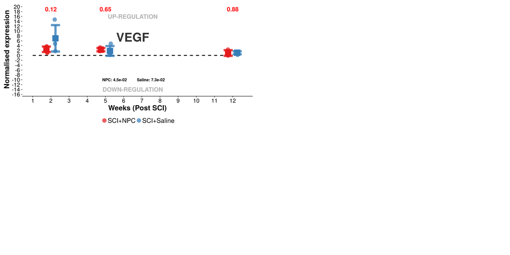

**Figure 4:** Each plot reports expression of one cytokine per treatment group and time point. Statistical analysis as described above. P-values for comparison of the two independent groups are presented at each time point. Color of p-value is gree if p-value < 0.05, orange if p-value>0.05 & p-value <0.1 and red if p-value >0.1. P-values for within treatment multiple comparison (over time) are presented in the lower part of the plot.